# Estimating Effect of Tax Incentives on Donations Considering Self-Selection of Tax Incentives in South Korea

Hiroki Kato

h-kato@econ.osaka-u.ac.jp

Tsuyoshi Goto

t.goto@chiba-u.jp

Youngrok Kim

2022/07/05

# Estimation Results

## Results of Fixed Effect Model

ベースラインとして、操作変数を用いない固定効果モデルの結果を示す

- 説明変数に用いる価格は、控除を申請するときに適用される価格（applicable price） と控除の有無による価格変動を考慮した現実の価格（effective price）の二つを用いる

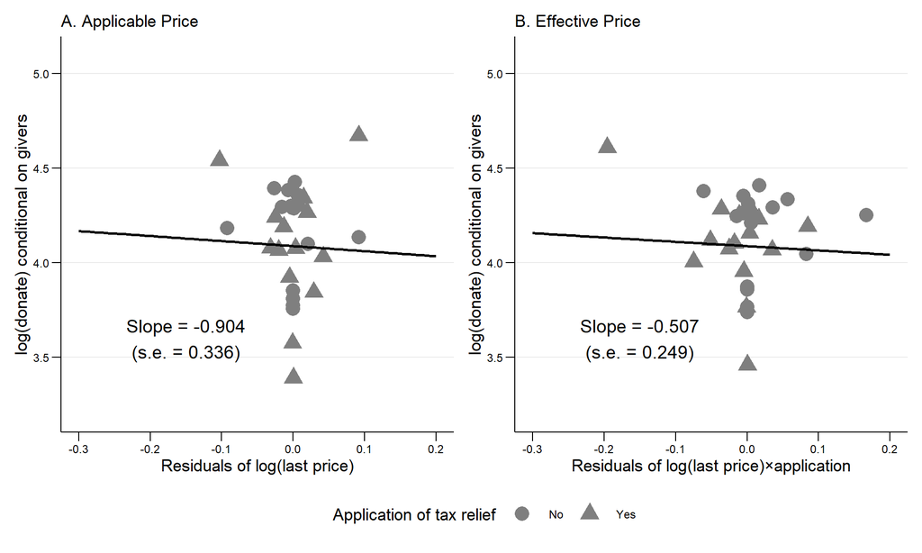

Figure 1: Relationship between Giving Amount and Residuals of Giving Price among Donors.

図1は寄付者に限定した寄付額と価格の関係を示している。

- 縦軸は寄付者の寄付額であり、横軸は価格の残差である。
  - 価格の残差は、価格以外の共変量と固定効果で価格を回帰するモデルから得ている。
- パネルAとBはそれぞれ、applicable priceとeffective priceを用いている。
- どちらのパネルについても、価格の残差がゼロのあたりにサンプルが集中している。
- どちらのパネルについても、控除申請の有無によって、寄付額に大きな差がない。

Regression anatomy theoremより、 価格の残差に関する寄付額の単直線回帰分析はintensive-marginの価格弾力性となる。 図1の二つのパネルに示した直線はこの回帰直線である。

- パネルAより、applicable priceを用いたintensive-marginの価格弾力性はおよそ-0.9である。
- パネルBより、effective priceを用いたintensive-marginの価格弾力性はおよそ-0.5である。
- 二つの価格弾力性の標準誤差を考慮すると、二つの価格弾力性の差は誤差の範囲であると考える。
- 二つの価格弾力性が似たような値を取った原因として、 控除を申請していない人の平均的な寄付額が、価格に関わらず、 控除を申請している人のそれと大きな差がないことにある。

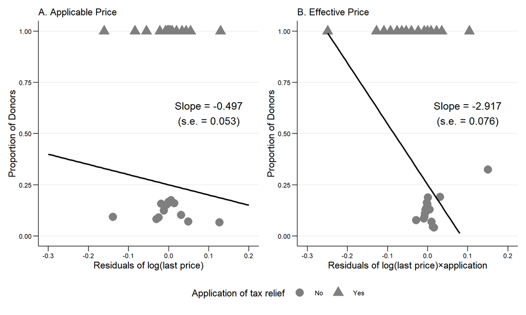

Figure 2: Relationship between Decision to Donate and Residuals of Giving Price.

図2は寄付行動と寄付価格の残差の関係を示している。

- アウトカム変数が二値なので、 この回帰直線の傾きをextensive-marginの価格弾力性として解釈できない。
  - 傾きの係数を寄付者割合で割ることによって、extensive-marginの価格弾力性を得る
- パネルAより、applicable priceを用いるとき、extensive-marginの価格弾力性は およそ-2.1($=-0.497 / 0.24$)である。
- パネルBより、effective priceを用いるとき、extensive-marginの価格弾力性は およそ-12.2($=-2.917 / 0.24$)である。
- effective priceを用いることによって、extensive-marginの価格弾力性はより弾力的になった。

## Results of FE-2SLS

ベースラインで示した固定効果モデルには2つの内生性が存在する。

1. 寄付価格が個人の寄付行動によって決まる
2. 寄付控除の申告が自己選択であること

これに対処するために、二段階固定効果モデル（FE-2SLS）を推定する。 操作変数は(1)applicable first-unit priceと(2)給与所得者ダミーである。

- first-unit priceは寄付額ゼロのときの寄付価格であり、寄付額とは独立に決まる。 また、寄付価格が低いほど、寄付による節税の便益が大きいので、 この変数は申告による便益を捉えている。
- 給与所得者は、自営業者と比較して、簡単に寄付控除を申告出来るので、 給与所得者ダミーは寄付控除の申告コストの代理変数となる。

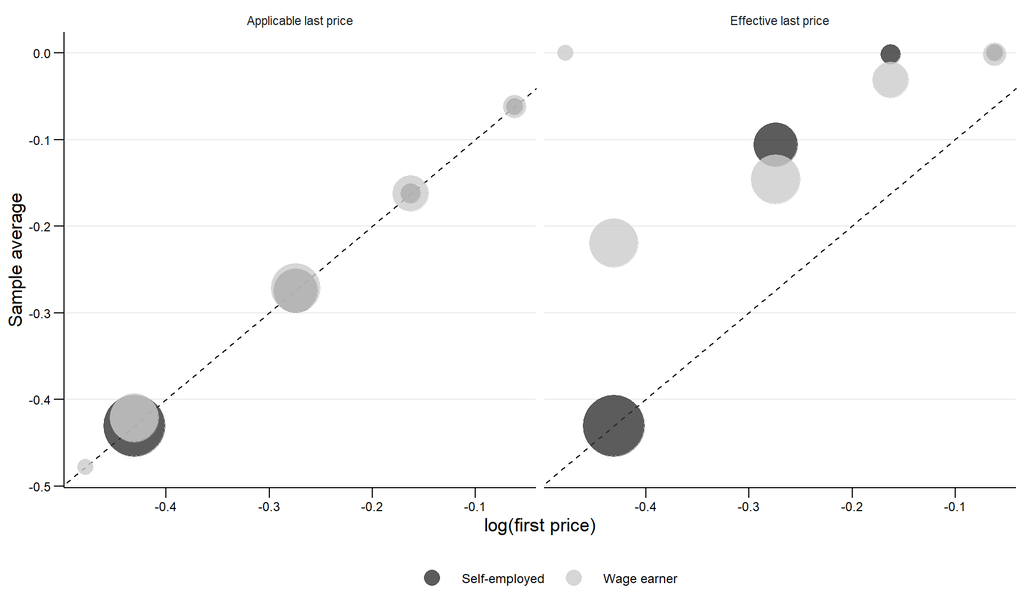

Figure 3: Relationship between Applicable First Price and Last Price by Employment Status. Note: The bubble size indicates the percentage of donation deductions claimed. Due to the small sample size, the leftmost bubbles for salaried and self-employed workers are less informative ($N=6$ for wage earner and $N=2$ for self-employed).

操作変数に関する我々の予測が成立していることをデータから確認する。

Table 1: Results of Regression of Effective Last Price

Sample:

Intensive-margin

Extensive-margin

log(first price)

0.706***

0.679***

0.356***

0.328***

(0.045)

(0.080)

(0.021)

(0.020)

log(first_price)×wage earner

0.529***

0.028

0.270***

0.041***

(0.043)

(0.067)

(0.020)

(0.016)

Num.Obs.

6247

6247

6247

24984

24982

24982

給与所得者が相対的に控除を申請しやすいのであれば、 給与所得者に限定したeffective last priceとapplicable first priceの相関は 自営業主のそれよりも強くなるはずである。

Table 2: Tax-Price Elasticity Estimated by FE-2SLS

Intensive-margin

Extensive-margin

Effective last price

－1.879***

－1.699**

－1.872***

－1.469***

－1.046***

－1.433***

(0.602)

(0.730)

(0.602)

(0.150)

(0.207)

(0.150)

log(income)

0.726

0.855

0.731

1.761***

1.967***

1.779***

(1.506)

(1.536)

(1.506)

(0.285)

(0.311)

(0.286)

Num.Obs.

6247

6247

6247

24984

24982

24982

First-Stage model

F-statistics of instruments

1028.00

698.82

514.26

2619.68

1396.10

1319.61

Wu-Hausman test, p-value

0.001

0.019

0.001

0.000

0.000

0.000

Notes: $^{*}$ $p &lt; 0.1$, $^{**}$ $p &lt; 0.05$, $^{***}$ $p &lt; 0.01$. Standard errors are clustered at household level. A square bracket is F statistics of instrument.

表2はFE-2SLSの第二段階の推定結果を示している。

- 寄付者に限定すると、寄付額に対するeffective last priceの価格弾力性は -1.9から-1.7の範囲で得られた。 これは通常の固定効果モデルの価格弾力性よりも3倍弾力的であり、 Wu-Hausman検定より統計的に有意な差である。 また、F値が500以上あるので、この結果の差は操作変数の弱相関による問題ではない。
- 寄付行動をアウトカムとするとき、effective last priceの係数は-1.5から-1の範囲で得られた。 価格弾力性に変換するために、この係数を寄付者比率で割ると、 価格弾力性は-6.25から-4.17の範囲となる。 これは通常の固定効果モデルの価格弾力性の半分以下とであり、 Wu-Hausman検定より統計的に有意な差である。 また、F値が1000以上あるので、この結果の差は操作変数の弱相関による問題ではない。

Table 3: Price Elasticity without Announcement Effect

Intensive-margin

Extensive-margin

Effective last price

－2.049**

－1.857

－2.048**

－1.444***

－0.822**

－1.395***

(0.916)

(1.213)

(0.916)

(0.220)

(0.327)

(0.219)

log(income)

－0.620

－0.526

－0.619

1.870***

2.128***

1.891***

(2.129)

(2.152)

(2.129)

(0.350)

(0.382)

(0.351)

Num.Obs.

4463

4463

4463

16956

16954

16954

First-Stage model

F-statistics of instruments

670.87

387.42

335.28

1453.69

720.82

731.93

Wu-Hausman test, p-value

0.007

0.074

0.007

0.000

0.000

0.000

Notes: $^{*}$ $p &lt; 0.1$, $^{**}$ $p &lt; 0.05$, $^{***}$ $p &lt; 0.01$. Standard errors are clustered at household level. A square bracket is F statistics of instrument.

結果の頑健性について議論する。 始めに、2014年の税制改革のアナウンスメント効果と学習効果に対応する

- 2014年の税制改革は2013年に告知されているので、 インセンティブの縮小を予測した納税者は2013年の寄付を増やし、2014年の寄付を減らすかもしれない。
- また、事前告知によってインセンティブが拡大する所得層の納税者の一部は、 制度をよく理解していないので、2014年の寄付をためらうかもしれない。
- 価格弾力性の推定において、これらの要素はconfounderとなるので、 2013年と2014年のデータを排除してFE-2SLSモデルを推定する。
- 表3より、 intensive-margin price elasticityは若干弾力的になった、 一方で、extensive-margin price elasticityは若干非弾力的になった。
- ただし、標準誤差を考慮すると、係数の変化は誤差の範囲だと考えられ、 FE-2SLSの推定結果は制度のアナウンスメント効果や学習効果に対して頑健である。

Table 4: Estimating Intensive-Margin Price Elasticities for Those Who Applied for Tax Relief

Model:

FE

FE-2SLS

log(last price)

－0.937**

0.139

－1.356***

0.139

(0.441)

(0.955)

(0.458)

(0.955)

log(income)

1.480

－0.554

1.394

－0.554

(1.542)

(5.384)

(1.531)

(5.384)

1-year lag of price

－0.204

－0.204

(0.869)

(0.869)

1-year lag of income

7.042

7.042

(4.852)

(4.852)

1-year lead of income

－2.347

－2.347

(3.143)

(3.143)

Num.Obs.

3479

800

3479

800

F-statistics of instrument

2869.0

0.0

Notes: $^{*}$ $p &lt; 0.1$, $^{**}$ $p &lt; 0.05$, $^{***}$ $p &lt; 0.01$. Standard errors are clustered at individual level. 1-year lead of price cannot be estimated because of collinearity.

Table 5: $k$-th Difference Model Using Those Who Applied for Tax Relief

1-year lag

2-year lag

3-year lag

Difference of logged first price

－1.965*

－2.569***

－4.070***

(1.145)

(0.912)

(0.730)

Difference of logged income

2.175

6.927

5.607*

(3.797)

(4.329)

(3.062)

First-stage: Instrument

0.988

0.985

0.973

[16293.6]

[18217.6]

[12017.6]

Num.Obs.

3526

3428

3303

Notes: $^{*}$ $p &lt; 0.1$, $^{**}$ $p &lt; 0.05$, $^{***}$ $p &lt; 0.01$. Standard errors are clustered at individual level. Instrument is difference between lagged first price in year $t$ and in year $t - k$ fixing income in year $t - k$.

次に、寄付控除を申告した人に限定した分析を行った（**フック欲しい**）。

- 寄付控除を申告している人は必ず寄付をしているので、 intensive-margin price elasticityのみを推定する
- その結果、last priceの価格弾力性は-1.3となり、FE-2SLSより非弾力的になった
- 価格のダイナミックな効果を捉えるために、寄付価格と所得のリード変数とラグ変数を加えると、 価格弾力性は統計的に非有意となった。ただし、サンプルサイズが少ないので、この結果はあまり意味がない。
- また、所得に対する寄付価格の内生性を考慮した$k$階差分モデルを推定した。 その結果、弾力性は-1.9から-4の範囲で得られた。

[figure not shown]

Table 6: First-Stage Results of FE-2SLS with Propensity Score

Sample:

Intensive-margin

Extensive-margin

Applicable first price

0.506***

0.104***

(0.071)

(0.022)

Applicable first price×Propensity score

0.842***

0.287***

0.736***

0.581***

(0.055)

(0.085)

(0.046)

(0.061)

log(income)

－0.075

－0.480**

0.174**

0.076

(0.175)

(0.195)

(0.070)

(0.072)

Num.Obs.

6247

6247

24982

24982

Notes: $^{*}$ $p &lt; 0.1$, $^{**}$ $p &lt; 0.05$, $^{***}$ $p &lt; 0.01$. Standard errors are clustered at household level. A square bracket is F statistics of instrument.

Table 7: Second-Stage Results of FE-2SLS with Propensity Score

Intensive-margin

Extensive-margin

Effective last price

－1.815***

－1.860***

－1.183***

－1.248***

(0.634)

(0.592)

(0.139)

(0.137)

log(income)

0.771

0.739

1.900***

1.869***

(1.501)

(1.500)

(0.288)

(0.287)

Num.Obs.

6247

6247

24982

24982

First-Stage model

F-statistics of instruments

902.95

530.45

3360.78

1728.15

Wu-Hausman test, p-value

0.004

0.001

0.000

0.000

Notes: $^{*}$ $p &lt; 0.1$, $^{**}$ $p &lt; 0.05$, $^{***}$ $p &lt; 0.01$. Standard errors are clustered at household level. A square bracket is F statistics of instrument.

寄付控除の申請が自己選択であることを制御するために、給与所得者ダミーを操作変数として用いている。 この代替的な手法として、寄付控除の申請の傾向スコアを給与所得者ダミーの代わりに用いる（**なぜこれする？**）。

- サンプルを年ごとに分割して、 給与所得者ダミー・Applicable first price・FE-2SLSで用いた共変量を説明変数としたプロビットモデルを推定した。
- 推定されたモデルから得られる予測値を傾向スコアとする。
- 表6は傾向スコアを操作変数として用いたFE-2SLSの第一段階の推定結果である。
- これまでの結果と整合的であり、寄付控除を申請しやすい人ほど、 applicable first priceとeffective last priceの相関が強くなる。
- 表7は傾向スコアを操作変数として用いたFE-2SLSの第二段階の推定結果である。
- これまでの結果と整合的であり、弾力性の値も大きく変化しない。

Table 8: First-Stage Results of FE-2SLS with Propensity Score (Pooled)

Sample:

Intensive-margin

Extensive-margin

Applicable first price

0.619***

0.108***

(0.084)

(0.028)

Applicable first price×Propensity score

0.937***

0.135

0.773***

0.587***

(0.067)

(0.123)

(0.053)

(0.083)

log(income)

－0.016

－0.594***

0.200***

0.079

(0.178)

(0.216)

(0.072)

(0.078)

Num.Obs.

6247

6247

24982

24982

Notes: $^{*}$ $p &lt; 0.1$, $^{**}$ $p &lt; 0.05$, $^{***}$ $p &lt; 0.01$. Standard errors are clustered at household level. A square bracket is F statistics of instrument.

Table 9: Second-Stage Results of FE-2SLS with Propensity Score (Pooled)

Intensive-margin

Extensive-margin

Effective last price

－1.805***

－1.870***

－1.050***

－1.157***

(0.612)

(0.597)

(0.143)

(0.140)

log(income)

0.779

0.732

1.965***

1.913***

(1.498)

(1.503)

(0.292)

(0.290)

Num.Obs.

6247

6247

24982

24982

First-Stage model

F-statistics of instruments

869.47

515.85

3102.47

1591.02

Wu-Hausman test, p-value

0.005

0.001

0.000

0.000

Notes: $^{*}$ $p &lt; 0.1$, $^{**}$ $p &lt; 0.05$, $^{***}$ $p &lt; 0.01$. Standard errors are clustered at household level. A square bracket is F statistics of instrument.

- また、全期間のサンプルで推定したプロビットモデルの傾向スコアを用いても、 同じ結果が得られる （第一段階の結果は表8に示し、 第二段階の結果は表9に示した）

# Discussion and Conclusion

寄付の控除申告の自己選択による内生性を制御したかどうかによって弾力性が大きく変化することが明らかになった。

これらの結果を統一的に解釈することを試みたい。

- 個人の弾力性が一定であると仮定する。このとき、推定量のバイアスは寄付の誤差項と控除申告の相関に依存する。 寄付控除の申告が節税の便益という利己的な動機に基づくものであれば、寄付をしている人ほど、寄付の控除を申告しやすい。 したがって、寄付の誤差項と控除申告は負の相関をしているので、固定効果モデルの価格弾力性は過大に推定されている。
- これは寄付行動に対する価格弾力性の変化を説明できるが、寄付者の寄付額の意思決定に対する価格弾力性の変化を説明できない。

寄付控除の申告が利他的な動機にも依存するのであれば、寄付の誤差項と控除申告は正の相関になる可能性がある。

- 行動経済学のいくつかの研究では、金銭的なインセンティブが献血や寄付などの利他的な行動を阻害している可能性を報告している。
- これは他人が自分をどのように評価しているかという社会的イメージで説明できる。
- 他人が当人を利他的であるかどうかを評価するとき、金銭的インセンティブの提供はノイズとなる。
- 社会規範などによって、利他的な人として評価されたい納税者は寄付控除を申告して、利己的な便益を得ようとは思わないだろう。
- この場合、寄付の誤差項と控除申告は正の相関となるので、固定効果モデルの価格弾力性は過小に推定される。
- したがって、寄付するかどうかの意思決定は利己的な動機が強く、いくら寄付するかという意思決定は利他的な動機が相対的に強い可能性がある。

寄付行動と控除の申告の動機が個人や時間によって異なるのであれば、弾力性が異質的であることは自然である。

- この場合、固定効果モデルは寄付の誤差項だけでなく、個人の弾力性と平均弾力性の差にも依存する。
- 一般的に、FE-2SLSは寄付の誤差項と控除申告の誤差項を排除できるが、 弾力性の異質性によって生じるバイアスを排除できない。
- このとき、その対応策として、control function approachやmarginal treatment effectが考えられる。 これらの方法を用いた推定は今後の課題である。